# Simulating Autoregressive (AR) Processes

This exercise is part of the [ECLR](https://datasquad.github.io/ECLR/) page.

## Introduction

Autoregressive processes are a basic building block of much of time-series econometrics. In this walkthrough we shall learn how to simulate such processes. This will also help with a good basic understanding of the properties of such processes.

As you will see, there is a very useful function that will help in simulating these processes, but we shall also use this to learn how to simulate processes yourself. This will be important for non-standard processes.

## A general autoregressive process

A general autoregressive process is represented by the following model

$$\begin{equation}
v_t = \alpha + \beta t + \gamma_1 v_{t-1} + \gamma_2 v_{t-2} + ... +
\gamma_p v_{t-p} + w_t
\end{equation}$$

where $w_t$ is a white noise process satisfying $E[w_t] = 0$, $Var[w_t] = \sigma^2$ and $Cov[w_t,w_{t-k}] = 0$ for all $k > 0$.

The above delivers a few well know specific processes

| Process Name for $v_t$ | Parameter restrictions |
| --- | --- |
| White noise | $\alpha = \beta = \gamma_i = 0$ for all $i$ |
| Deterministic Trend model | $\gamma_i = 0$ for all $i$ |
| Random walk | $\gamma_1 = 1$, $\alpha = \beta = \gamma_i = 0$ for all $i>1$ |
| Random walk with drift | $\gamma_1 = 1$, $\beta = \gamma_i = 0$ for all $i>1$ |
| AR(1) model | $\beta = \gamma_i = 0$ for all $i>1$ |
| AR(p) model | $\beta = 0$ |
| AR(p) model with deterministic trend | $\beta \ne 0$ |

## Simulating a general AR process

We will now learn how to simulate such processes

### An AR(1) process

An AR(1) process

$$\begin{equation}
v_t = \alpha + \gamma_1 v_{t-1} + w_t
\end{equation}$$

requires a number of pieces of information before we can simulate it. We need parameter values ($\alpha$ and $\gamma_1$). For now we shall set these to $\alpha=0$ and $\gamma_1=0.8$. We also need random terms $w_t$. In order to draw the latter we will need to know what distribution we should draw these from. For now we shall assume $w_t \sim N(0,1)$ although one could chosse different distributions as well. You also need to know how many $t$s you want to simulate, as $t$ goes from $t=1,...,T$.

In order to simulate the first observation $v_1$ we need to know what $v_0$ is. We call this value the starting value $v_0$. This is often set to 0. However, as you will soon see this may not always be an appropriate value.

```r
# Simulation parameters
T = 1000
alpha = 0
gamma = 0.8
v0 = 0

# Draw random terms, we draw T+1 to make life easier below
w = rnorm(T+1, 0, 1)   # draws T+1 values from the standard normal distribution

# store the simulated series here, T+1 elements as the first is v0
v = matrix(v0,T+1,1)
```

The last line created a container in which we save the simulated series. For now all values take the same value as $v0$ but soon we will replace values in cells 2 to $T+1$ with randomly simulated values following the above AR(1) process.

```r
for (t in seq(2,T+1)){
  v[t] = alpha + gamma * v[t-1] + w[t]
}
```

You can see that inside the loop we basically implemented the AR(1) process.

Why does the loop start with `t=2`?

Now we can plot this series.

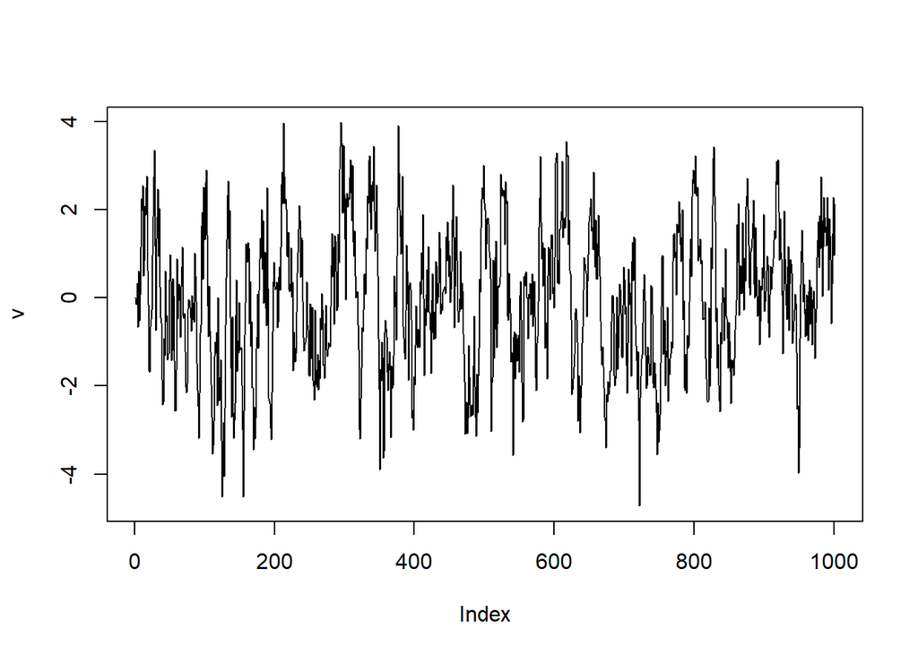

```r
plot(v, type = "l")  # type = "l" produces a line graph
```

This is your first simulated autoregressive series.

Experiment with the values the parameters take.

When $|\gamma_1|<1.0$ the process is stationary and always returns back to its unconditional mean, here 0. When $\gamma_1 = 1.0$ we have a random walk process which has no tendency to return to its unconditional mean.

### An AR(2) process

How would you have to change the code to simulate this AR(2) process:

$v_t = 10 + 0.5 v_{t-1} + 0.4 v_{t-2} + w_t$?

This requires a change in some parameters but also the addition of a second lag inside the loop.

```r
# Simulation parameters
T = 1000
alpha = 10
gamma1 = 0.5
gamma2 = 0.4
v0 = 0

# Draw random terms, we draw T+2 to make life easier below
w = rnorm(T+2, 0, 1)

# store the simulated series here, T+2 elements as the first two are v0
v = matrix(v0,T+2,1)

for (t in seq(3,T+2)){
  v[t] = alpha + gamma1 * v[t-1] + gamma2 * v[t-2] + w[t]
}
```

Your series should look something like this.

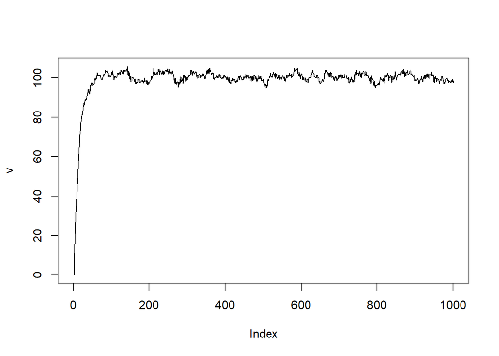

```r
plot(v, type = "l")
```

You can see that the process starts with 0 but then moves up to fluctuate around the value of 100. The reason for that is that for a stationary AR(2) process the unconditional mean value of the process will be $E[v_t]=\frac{\alpha}{1-\gamma_1-\gamma_2}$, which, with our parameter values, is 100. A better starting value would be `v0 = alpha/(1-gamma1-gamma2)`. Alternatively you could still start with `v0 = 0` but simulate, say, 1200 observations and then discard the first 200 observations.

Previously we used a value of $\alpha = 0$ which meant that the the unconditional mean was also equal to 0.

Also note that the loop now started with `t=3` as we needed two starting values.

## Using `arima.sim`

The `arima.sim` function (part of the `stats` package) makes simulating such models very straightforward without you having to write any loops.

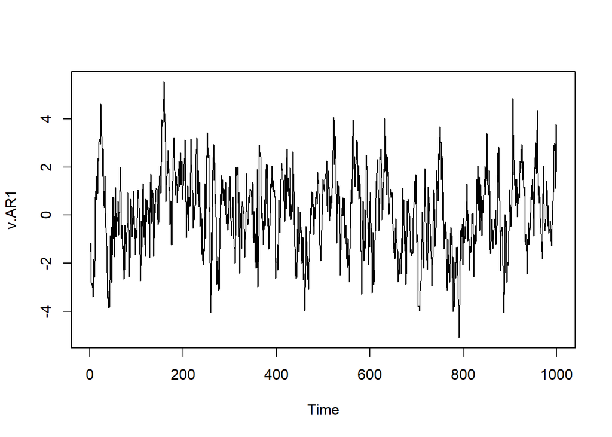

```r
v.AR1 <- arima.sim(n = 1000, list(ar = c(0.8),ma = c()), sd = sqrt(1))
plot(v.AR1, type = "l")
```

Note that `list(ar = c(0.8), ma = c())` sets and AR(1) model parameter of $\gamma_1=0.8$. There is provision for also allowing for moving average processes, but we leave that empty (`ma = c()`) as we are not using MA components here.

The AR(2) process we simulated earlier is now simulated as follows:

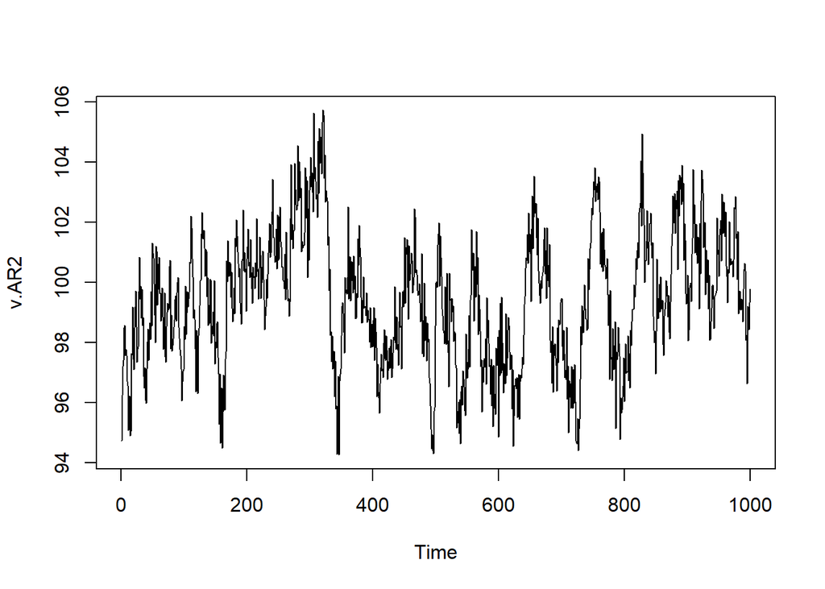

```r
v.AR2 <- arima.sim(n = 1000, mean = 10, list(ar = c(0.5,0.4),ma = c()), sd = sqrt(1))
plot(v.AR2, type = "l")
```

Here the input `mean = 10` sets $\alpha = 10$ and `ar = c(0.5,0.4)` sets $\gamma_1 = 0.5$ and $\gamma_2 = 0.4$.

Also note that the function does automatically take care of the starting value problem we encountered when we simulated the series "by hand".

## Extension

- Consult the help function (`?arima.sim`) to see what type of processes can be simulated.
- How would you have to change the code (in which you write the loop) to simulate an AR model with deterministic trend?
- How would you have to change the code (in which you write the loop) to simulate an ARMA model?

This exercise is part of the [ECLR](https://datasquad.github.io/ECLR/) page.